# Plotting Challenges #1

Flow cytometry plots

07 April 2021

## Data

This experiment is analysing the CD4+ and CD8+ T cells from mouse tumours, including the phenotype of the CD8+ T cells. The test groups are: Control – 9 samples, Drug 1 – 9 samples, Drug 2 – 9 samples. The starting data is the Excel file flow_output.xlsx, sheet called “Raw flow output”. Many thanks to Emily Lelliott, Oliaro Lab for kindly providing the data.

Download flow_output.xlsx

## Aim

Create an R script to make a reproducible plot that looks similar to plot 1A, 1B or 2 below. Through taking part in this challenge you will learn how to use R to import Excel files, wrangle data and create and customise plots.  
We’ll hold a Zoom on **Tuesday May 18th 4pm** to discuss solutions.

## Prerequisites

Basic familiarity with R and ggplot. This could be obtained from reading this [Introduction to R for Biologists](https://www.melbournebioinformatics.org.au/tutorials/tutorials/intro_R_biologists/intro_R_biologists/) material.

## Steps

**Plot 1A - Beginner**

Packages to read in the data and analyse it will be loaded. Excel data will be imported and wrangled for appropriate reading with ggplot. Finally a panel of dot plots like Plot 1A will be generated.

1. Load any packages needed.
2. Import the data from the Excel file.
3. Remove the rows not needed for the plot (in column “Sample:”, rows containing “Mean” and “SD”).
4. Format the data to plot with ggplot.
5. Create one plot for each cell type (plot 1A).

**Plot 1B - Intermediate**

In addition to the steps above, the plot will be customised. A line will be added through the median of the points in each group. The colours, points, labels, title and background will be altered and the legend removed. A panel of dot plots like Plot 1B will be generated.

6. Add a line through the median of the points in each group.
7. Colour the groups choosing any colours you like.
8. Make the points bigger.
9. Change the x and y axis labels.
10. Add a title.
11. Remove the legend.
12. Format the background.

**Plot 2 - Advanced**

In addition to the steps above, calculations will be performed on the data to generate normalised counts. A panel of dot plots like Plot 2 will be generated.

13. Calculate the normalised counts per bead for each cell type. Total number of beads is 3000.
14. Calculate the normalised counts per gram tumour for each cell type. Control and Drug 1 tumour weights were 0.1g, Drug 2 was 0.2g.
15. Format the data to plot with ggplot.
16. Create one plot for each cell type like plot 2.

**Optional**  
Add any other customisations you like (e.g. change colour/shape/transparency of points, add a legend, angle the x axis labels) or create a different plot type for the data.

## Plot 1A

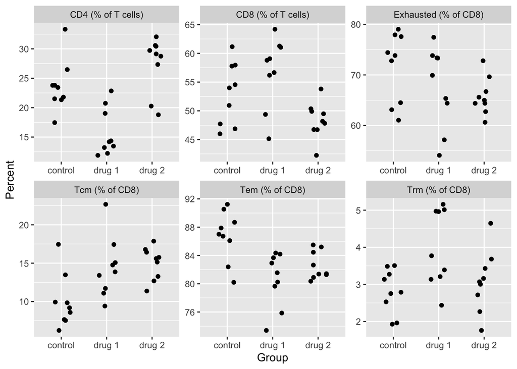

## Plot 1B

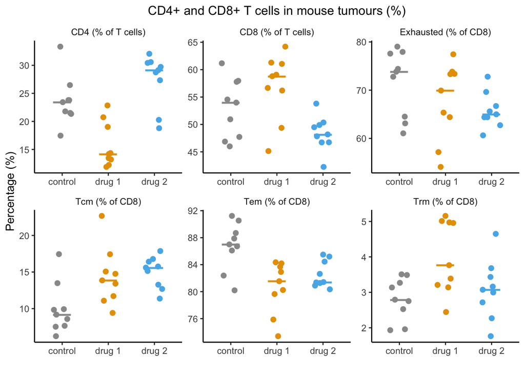

## Plot 2

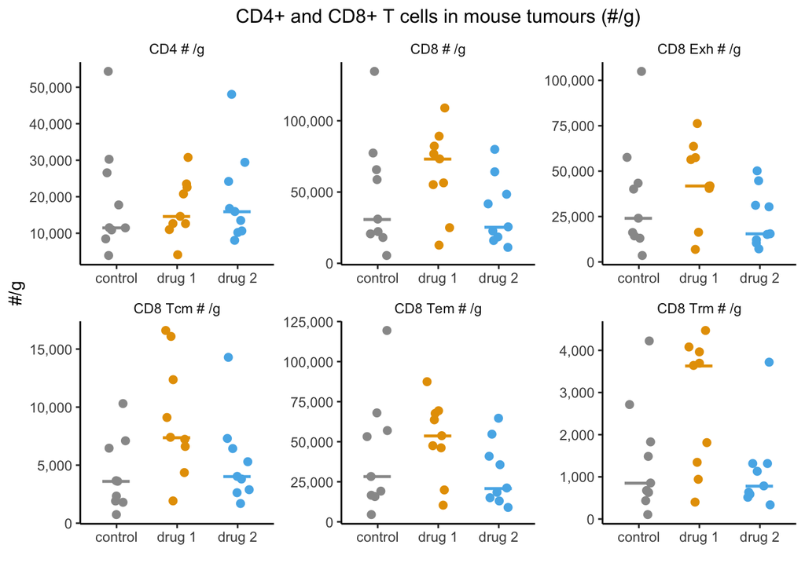

## Getting started

- To get started either
  - Download and install [R](https://cran.r-project.org/) and [RStudio](https://rstudio.com/products/rstudio/download/#download) onto your computer if you don’t already have them. Install [tidyverse package](https://www.tidyverse.org/packages/#installation-and-use). Download Excel file from link in **Data** section above.
  - Or use an Rstudio Cloud project that has everything set up. Click on this [RStudio project link](https://rstudio.cloud/project/2292770) (create a free RStudio Cloud account if you don’t have one). Note: When the project opens, click top menu “Save a Permanent Copy” if you want any edits you make to be saved.

## Additional Resources

- [ggplot2 graph gallery](https://www.r-graph-gallery.com/ggplot2-package.html)
- [ggplot2: elegant graphics for data analysis book](https://ggplot2-book.org/)
- [R for Data Science book](https://r4ds.had.co.nz/)
- [DataCamp Interactive courses](https://www.datacamp.com/search?utf8=%E2%9C%93&q=&tab=courses&facets%5Btechnology%5D%5B%5D=R&facets%5Btopic%5D%5B%5D=Data+Manipulation&facets%5Btopic%5D%5B%5D=Data+Visualization) such as [Introduction to Data Visualization with ggplot2](https://www.datacamp.com/courses/introduction-to-data-visualization-with-ggplot2). Contact Maria if you would like access.

## Acknowledgements

Thanks to Andrew Guirguis, Emily Lelliott and Cassie Litchfield for input and feedback.

## Contact

Contact Maria Doyle (maria.doyle@petermac.org) to be added to the mailing list to be notified of any updates and to get the Zoom invite. Please also feel free to get in contact if you have any questions or need help.